# 多元统计分析R语言应用——聚类分析

## 快速Kmeans聚类法

该算法适用于样本容量不是很大的时候，对计算机性能要求不高。基本思想是将每一个样品分配给最近中心的类中。K均值法只能产生只能类数的聚类结果。

Kmeans算法以\( k \)为参数,把n个对象分为\( k \)个聚类，以使聚类内具有较高的相似度，而聚类间的相似度较低。

R语言函数

```
kmeans(x,centers,...)
x为数据矩阵或数据框
centers为聚类数或出事聚类中心
```

#### 例题

对随机数进行聚类分析

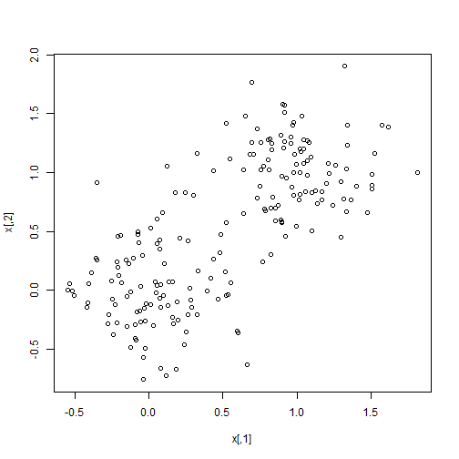

```r
x1 = matrix(rnorm(1000, mean = 0, sd = 0.3), ncol = 10)  #生成1000个均值为0，标准差为0.3的10列100行的正态随机矩阵。
x2 = matrix(rnorm(1000, mean = 1, sd = 0.3), ncol = 10)  #生成1000个均值为1，标准差为0.3的10列100行的正态随机矩阵。
x = rbind(x1, x2)  #将x1和x2拼接起来
plot(x)  # 绘制x图形
```

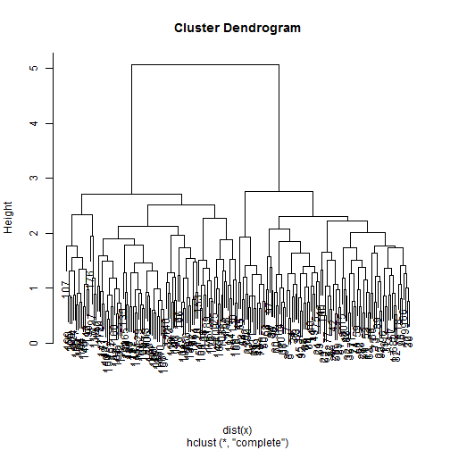

```r
plot(hclust(dist(x), method = "complete"))  #用最长距离法进行聚类
```

```r
(cl = kmeans(x, 2))  #用Kmeans聚类法进行聚类
```

```
## K-means clustering with 2 clusters of sizes 100, 100
##
## Cluster means:
##      [,1]     [,2]    [,3]       [,4]     [,5]     [,6]    [,7]    [,8]
## 1 0.98984 1.013402 1.02397  0.9544495 1.023591  0.97590 1.02497 1.02384
## 2 0.03019 0.007272 0.02609 -0.0006242 0.006982 -0.02537 0.01674 0.01616
##       [,9]     [,10]
## 1  1.03180  0.989378
## 2 -0.05343 -0.003422
##
## Clustering vector:
##   [1] 2 2 2 2 2 2 2 2 2 2 2 2 2 2 2 2 2 2 2 2 2 2 2 2 2 2 2 2 2 2 2 2 2 2 2
##  [36] 2 2 2 2 2 2 2 2 2 2 2 2 2 2 2 2 2 2 2 2 2 2 2 2 2 2 2 2 2 2 2 2 2 2 2
##  [71] 2 2 2 2 2 2 2 2 2 2 2 2 2 2 2 2 2 2 2 2 2 2 2 2 2 2 2 2 2 2 1 1 1 1 1
## [106] 1 1 1 1 1 1 1 1 1 1 1 1 1 1 1 1 1 1 1 1 1 1 1 1 1 1 1 1 1 1 1 1 1 1 1
## [141] 1 1 1 1 1 1 1 1 1 1 1 1 1 1 1 1 1 1 1 1 1 1 1 1 1 1 1 1 1 1 1 1 1 1 1
## [176] 1 1 1 1 1 1 1 1 1 1 1 1 1 1 1 1 1 1 1 1 1 1 1 1 1
##
## Within cluster sum of squares by cluster:
## [1] 94.65 96.82
##  (between_SS / total_SS =  72.5 %)
##
## Available components:
##
## [1] "cluster"      "centers"      "totss"        "withinss"
## [5] "tot.withinss" "betweenss"    "size"
```

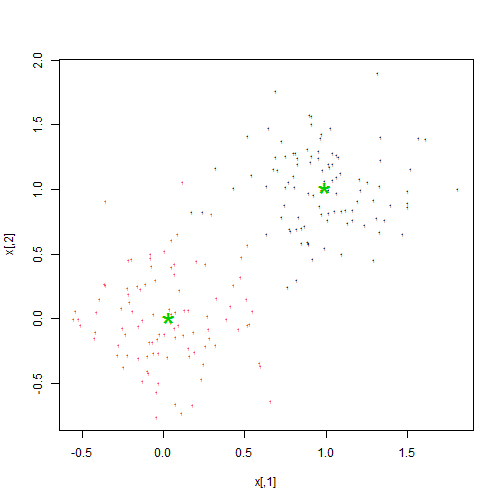

```r
pch1 = rep("1", 1000)
pch2 = rep("2", 1000)  #生成两组1000长度的标记文字
plot(x, col = cl$cluster, pch = c(pch1, pch2), cex = 0.4)  #绘制快速聚类分析的结果图，并标记结果
points(cl$centers, col = 3, pch = "*", cex = 3)  #标记中心
```

## 总结

- 聚类分析较为客观、直观、并且能够克服单一指标分类的弊端。
- kmeans算法只有在类的平均值被定义的情况下才能使用，必须事先给出k，可以结合系统聚类法先计算少量的值对其聚类，计算k值后，再用kmeans算法进行计算。
- 数据的不同维度之间的量纲不同也可以进行聚类，当通常需要进行变换，常用的变换有：平移变换、极差变换、标准差变换、主成分变换、对数变换等等。
- 两个变量间的相似程度越高，其距离越小或相似系数的绝对值越大，反之亦然。